# Case Study: Anthropometric Data

### Exploratory Analysis 3

#### Filter the datasets for `gender`

Filter the data so it contains only males and females, since all other categories have too few observations for meaningful analysis. Hint: Use a filter with `%in%` to get the groups you want.

```r
anthroMFonly <- anthro %>%
  filter(gender %in% c("male", "female"))
```

#### Faceted histogram

Create a histogram for `height` faceted by `gender`, with the two plots arranged one above the other (so they will share a common x-axis scaling the final plot). Do the same for `armspan`.

Since histograms already have two quantitative axes (the variable on `x` and the count on `y`), we need to `facet` if we want to compare groups. Faceting is similar to a `group_by()` for plots. The `facet_grid()` lets us specify a matrix or “grid” arrangement for plots using a row variable and a column variable, as `facet_grid(rowvar ~ colvar)`. Using `gender` as the row variable means the plots will have the same x-axis and same bins. We only want to facet by one variable, so we replace the other with a `.`

Here I added some axis scaling so we can see the measurements more clearly. The `breaks` are the locations of the axis tick marks. Notice what I call the “six foot bump” at about 72" in the male graph. Where do you think that comes from?

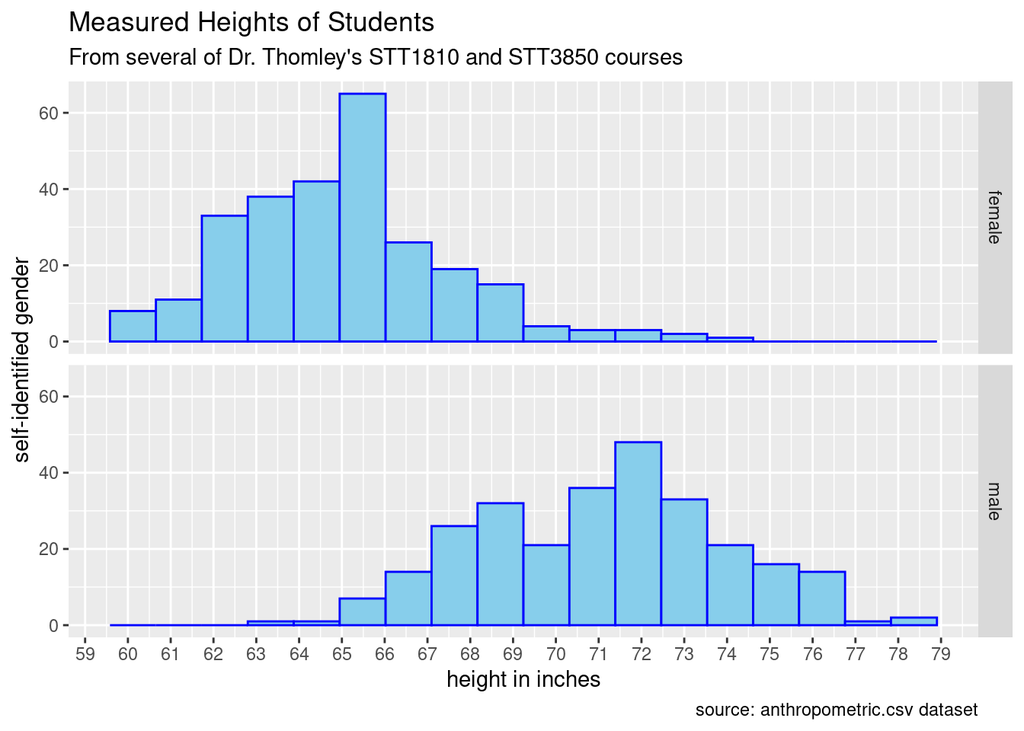

```r
ggplot(anthroMFonly, aes(x = height)) +
  geom_histogram(bins = 18, fill = "skyblue", color = "blue") +
  scale_x_continuous(breaks = seq(from = 0, to = 100, by = 1)) + # tick marks
  facet_grid(gender ~ .) +
  labs(title = "Measured Heights of Students",
       subtitle = "From several of Dr. Thomley's STT1810 and STT3850 courses",
       x = "height in inches",
       y = "self-identified gender",
       caption = "source: anthropometric.csv dataset")
```

#### Faceted density plot

Create a density plot for `ideal` faceted by `gender`, with the two plots arranged one above the other (so they will share a common x-axis scaling in the final plot).

Notice that the peaks are in different places on the x-axis for female and male distributions. This is why the combined distribution you explored above is bimodal.

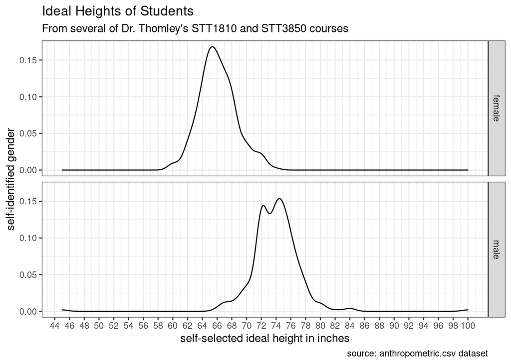

```r
ggplot(anthroMFonly, aes(x = ideal)) +
  geom_density() +
  scale_x_continuous(breaks = seq(from = 0, to = 100, by = 2)) +
  facet_grid(gender ~ .) +
  labs(title = "Ideal Heights of Students",
       subtitle = "From several of Dr. Thomley's STT1810 and STT3850 courses",
       x = "self-selected ideal height in inches",
       y = "self-identified gender",
       caption = "source: anthropometric.csv dataset") +
  theme_bw() # changes thematic elements like bg color
```

```r
# https://ggplot2.tidyverse.org/reference/ggtheme.html
```

We could also layer the density plots, for a different view.

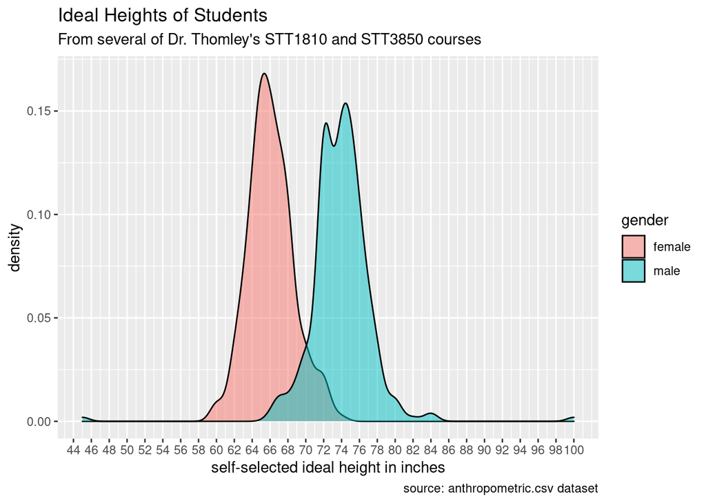

```r
ggplot(anthroMFonly, aes(x = ideal, fill = gender)) +
  geom_density(alpha = 0.5) +
  scale_x_continuous(breaks = seq(from = 0, to = 100, by = 2)) +
  labs(title = "Ideal Heights of Students",
       subtitle = "From several of Dr. Thomley's STT1810 and STT3850 courses",
       x = "self-selected ideal height in inches",
       caption = "source: anthropometric.csv dataset")
```

#### Comparative boxplot

Create comparative boxplots for `height` split by `gender`. Also calculate the upper and lower fences for each gender. Do the same for `ideal` height.

Boxplots only have one quantitative axis, so we can group by specifying a categorical variable for the other axis. Boxplots may be horizontal or vertical. Making them horizontal keeps the x-axis consistent with the other plots.

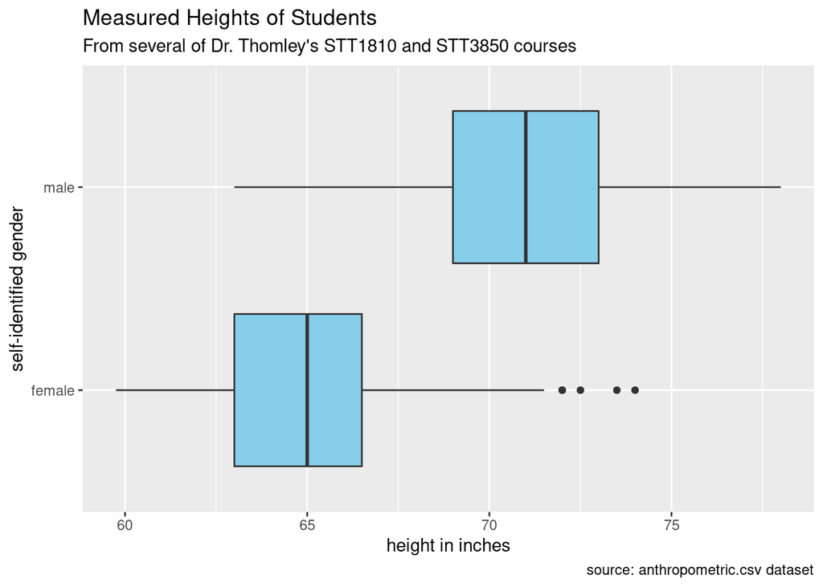

```r
# horizontal
ggplot(anthroMFonly, aes(x = height, y = gender)) +
  geom_boxplot(fill = "skyblue") +
  labs(title = "Measured Heights of Students",
       subtitle = "From several of Dr. Thomley's STT1810 and STT3850 courses",
       x = "height in inches",
       y = "self-identified gender",
       caption = "source: anthropometric.csv dataset")
```

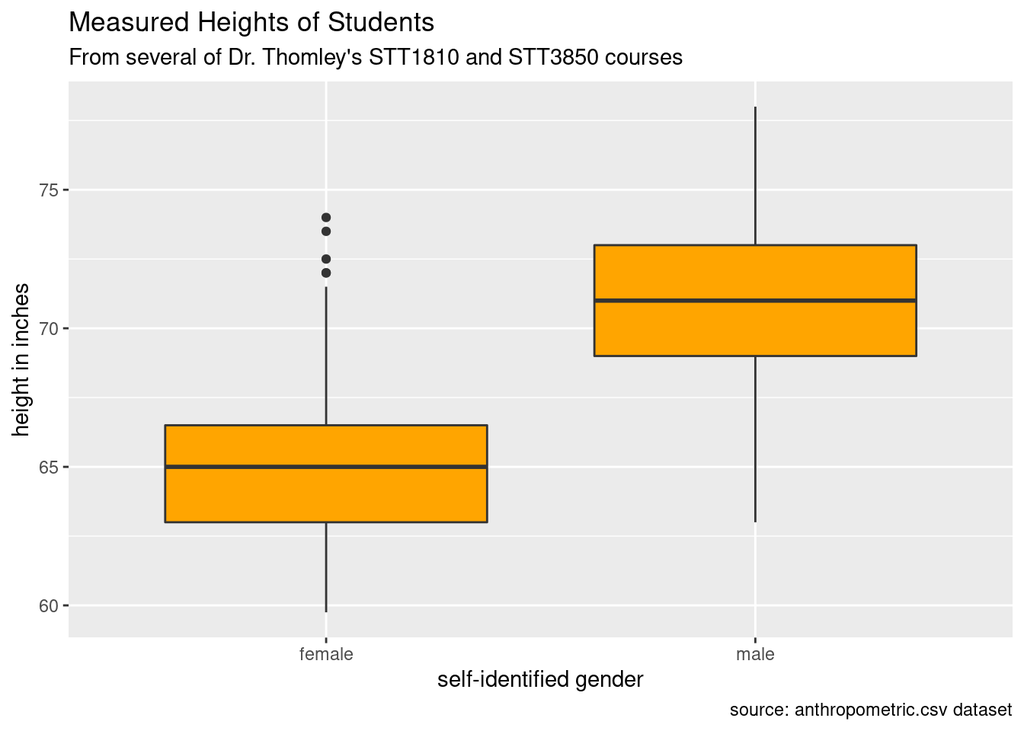

```r
# vertical
ggplot(anthroMFonly, aes(x = gender, y = height)) +
  geom_boxplot(fill = "orange") +
  labs(title = "Measured Heights of Students",
       subtitle = "From several of Dr. Thomley's STT1810 and STT3850 courses",
       x = "self-identified gender",
       y = "height in inches",
       caption = "source: anthropometric.csv dataset")
```

If we want the plots to be different colors, we need to `fill` with our grouping variable in the aesthetics rather than specify a color in the `geom`. Then we can choose our colors with `scale_fill_manual()` or a similar fill function such as `scale_fill_brewer()`.

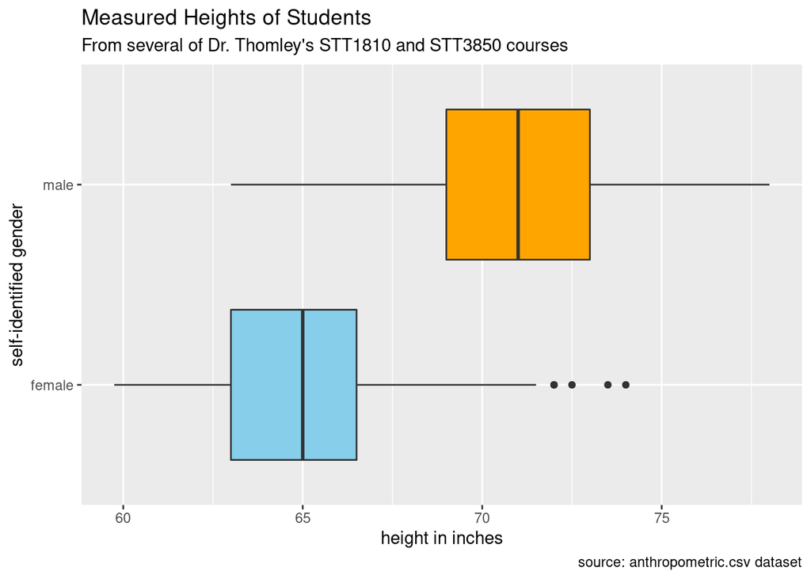

```r
ggplot(anthroMFonly, aes(x = height, y = gender, fill = gender)) +
  geom_boxplot() +
  labs(title = "Measured Heights of Students",
       subtitle = "From several of Dr. Thomley's STT1810 and STT3850 courses",
       x = "height in inches",
       y = "self-identified gender",
       caption = "source: anthropometric.csv dataset") +
  scale_fill_manual(values = c("skyblue", "orange")) +
  theme(legend.position = "none") # removes the redundant legend
```

### Concluding Discussions

*I will leave you to think a bit more about these for now…*

#### Overall distribution shapes

What are the overall shapes for the distributions of `height`, `armspan`, and `ideal`? Are they all unimodal? Are there any outliers?

#### Comparing male and female

Are there differences in distribution between males and females for `height`, `armspan`, and `ideal` height in this sample? Describe those differences.

#### Representativeness

What makes this sample *not* representative of people as a whole?

### BONUS: Using `grid.arrange()`

The `grid.arrange()` function allows us to group multiple plots into a useful or pleasing display of our choice. For several more options, see http://www.sthda.com/english/wiki/wiki.php?id_contents=7930.

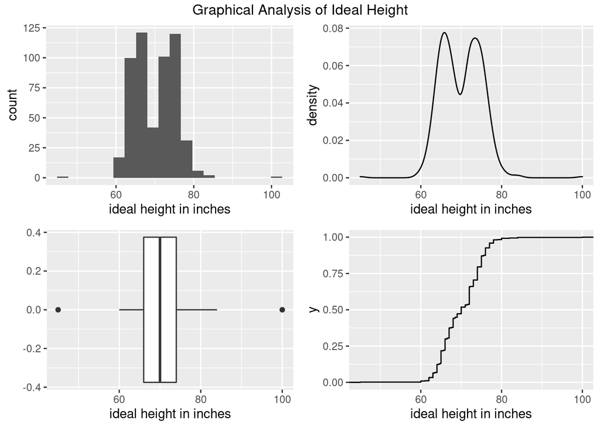

```r
# histogram
plotA <- ggplot(anthro, aes(x = ideal)) +
  geom_histogram(bins = 20) +
  labs(x = "ideal height in inches")

# density
plotB <- ggplot(anthro, aes(x = ideal)) +
  geom_density() +
  labs(x = "ideal height in inches")

# horizontal boxplot
plotC <- ggplot(anthro, aes(x = ideal)) +
  geom_boxplot() +
  labs(x = "ideal height in inches",
       y = "")   # helps with spacing here

# ECDF plot
plotD <- ggplot(anthro, aes(x = ideal)) +
  stat_ecdf() +
  labs(x = "ideal height in inches")

# vertical boxplot
plotE <- ggplot(anthro, aes(y = ideal)) +
  geom_boxplot() +
  labs(y = "ideal height in inches")

grid.arrange(plotA, plotB, plotC, plotD, nrow = 2, ncol = 2,
             top = textGrob("Graphical Analysis of Ideal Height"))
```

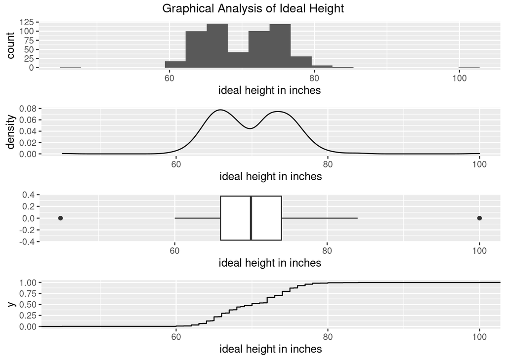

```r
grid.arrange(plotA, plotB, plotC, plotD, nrow = 4,
             top = textGrob("Graphical Analysis of Ideal Height"))
```

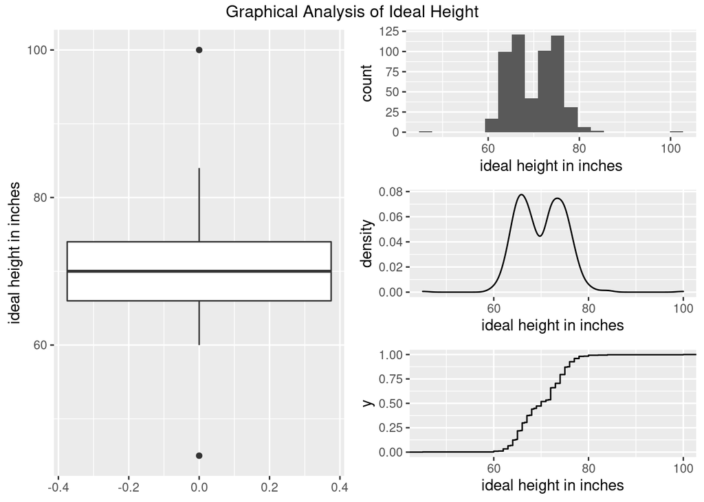

```r
grid.arrange(plotE, arrangeGrob(plotA, plotB, plotD), ncol = 2,
             top = textGrob("Graphical Analysis of Ideal Height"))
```